# RBioFormats: an R interface to the Bio-Formats library

Andrzej Oleś

3 October 2022

#### Package

RBioFormats 0.99.0 (Bio-Formats library version: 6.10.1)

# 1 Reading images

```r
library("RBioFormats")
```

Read a greyscale image

```r
f = system.file("images", "sample.png", package = "EBImage")

img = read.image(f)
img
```

```
## AnnotatedImage
##   colorMode    : Grayscale
##   storage.mode : double
##   dim          : 768 512
##   dimorder     : x y
##   frames.total : 1
##   frames.render: 1
##
## imageData(object)[1:5,1:6]
##       y
## x           [,1]      [,2]      [,3]      [,4]      [,5]      [,6]
##   [1,] 0.4470588 0.4627451 0.4784314 0.4980392 0.5137255 0.5294118
##   [2,] 0.4509804 0.4627451 0.4784314 0.4823529 0.5058824 0.5215686
##   [3,] 0.4627451 0.4666667 0.4823529 0.4980392 0.5137255 0.5137255
##   [4,] 0.4549020 0.4666667 0.4862745 0.4980392 0.5176471 0.5411765
##   [5,] 0.4627451 0.4627451 0.4823529 0.4980392 0.5137255 0.5411765
##
## metadata
##  $ coreMetadata:List of 18
```

or an RGB image

```r
f = system.file("images", "sample-color.png", package = "EBImage")

img = read.image(f)
img
```

```
## AnnotatedImage
##   colorMode    : Color
##   storage.mode : double
##   dim          : 768 512 3
##   dimorder     : x y c
##   frames.total : 3
##   frames.render: 1
##
## imageData(object)[1:5,1:6,1]
##           [,1]      [,2]      [,3]      [,4]      [,5]      [,6]
## [1,] 0.4549020 0.4784314 0.4941176 0.5137255 0.5294118 0.5529412
## [2,] 0.4588235 0.4784314 0.4941176 0.4980392 0.5215686 0.5490196
## [3,] 0.4705882 0.4823529 0.4980392 0.5137255 0.5294118 0.5372549
## [4,] 0.4666667 0.4745098 0.5058824 0.5137255 0.5450980 0.5647059
## [5,] 0.4705882 0.4705882 0.4901961 0.5137255 0.5372549 0.5647059
##
## metadata
##  $ coreMetadata:List of 18
```

Object summary without the image data preview can be printed using the `short = TRUE` argument to `print`.

```r
print(img, short = TRUE)
```

```
## AnnotatedImage
##   colorMode    : Color
##   storage.mode : double
##   dim          : 768 512 3
##   dimorder     : x y c
##   frames.total : 3
##   frames.render: 1
##
## metadata
##  $ coreMetadata:List of 18
```

For displaying only the dimension order use

```r
dimorder(img)
```

```
## [1] "x" "y" "c"
```

# 2 The *AnnotatedImage* class

*RBioFormats* stores image data in an *AnnotatedImage* class which extends the *Image* class from *EBImage*.

```r
getClassDef("AnnotatedImage")
```

```
## Class "AnnotatedImage" [package "RBioFormats"]
##
## Slots:
##
## Name:          .Data      metadata     colormode
## Class:         array ImageMetadata       integer
##
## Extends:
## Class "Image", directly
## Class "array", by class "Image", distance 2
## Class "structure", by class "Image", distance 3
## Class "vector", by class "Image", distance 4, with explicit coerce
```

Compared to the original *Image* class the *AnnotatedImage* class features an additional `metadata` slot containing image metadata.

```r
meta = metadata(img)
meta
```

```
## ImageMetadata
##  $ coreMetadata:List of 18
##   ..$ sizeX    : int 768
##   ..$ sizeY    : int 512
##   ..$ sizeZ    : int 1
##   ..$ sizeC    : int 3
##   ..$ sizeT    : int 1
##   ..$ pixelType: chr "uint8"
##   .. [list output truncated]
```

To alter the length of the printed output use the `list.len` attribute to `print`:

```r
print(meta, list.len=99L)
```

```
## ImageMetadata
##  $ coreMetadata:List of 18
##   ..$ sizeX           : int 768
##   ..$ sizeY           : int 512
##   ..$ sizeZ           : int 1
##   ..$ sizeC           : int 3
##   ..$ sizeT           : int 1
##   ..$ pixelType       : chr "uint8"
##   ..$ bitsPerPixel    : int 8
##   ..$ imageCount      : int 3
##   ..$ dimensionOrder  : chr "XYCZT"
##   ..$ orderCertain    : logi TRUE
##   ..$ rgb             : logi FALSE
##   ..$ littleEndian    : logi FALSE
##   ..$ interleaved     : logi TRUE
##   ..$ falseColor      : logi FALSE
##   ..$ metadataComplete: logi FALSE
##   ..$ thumbnail       : logi FALSE
##   ..$ series          : int 1
##   ..$ resolutionLevel : int 1
```

# 3 Image metadata

Image metadata is represented by an *ImageMetadata* class structured as a named list of coreMetadata, globalMetadata and seriesMetadata.

```r
names(meta)
```

```
## [1] "coreMetadata"   "seriesMetadata" "globalMetadata"
```

```r
cMeta = meta$coreMetadata
names( cMeta )
```

```
##  [1] "sizeX"            "sizeY"            "sizeZ"            "sizeC"
##  [5] "sizeT"            "pixelType"        "bitsPerPixel"     "imageCount"
##  [9] "dimensionOrder"   "orderCertain"     "rgb"              "littleEndian"
## [13] "interleaved"      "falseColor"       "metadataComplete" "thumbnail"
## [17] "series"           "resolutionLevel"
```

`coreMetadata` stores information which is guaranteed to exist for any image type, whereas the latter two metadata types are format-specific and can be empty.

Each of these metadata sublists has an correspodning accessor function, e.g.,

```r
identical( coreMetadata(meta), cMeta)
```

```
## [1] TRUE
```

and similarly for `globalMetadata` and `seriesMetadata`. These accessors are useful for extracting the corresponding metadata directly from an *AnnotatedImage* object

```r
identical( coreMetadata(img), cMeta )
```

```
## [1] TRUE
```

# 4 Reading image metadata

Image metadata can be read without loading the corresponding pixel data.

```r
f = system.file("images", "nuclei.tif", package = "EBImage")
metadata = read.metadata(f)

metadata
```

```
## ImageMetadata
##  $ coreMetadata  :List of 18
##   ..$ sizeX    : int 510
##   ..$ sizeY    : int 510
##   ..$ sizeZ    : int 1
##   ..$ sizeC    : int 1
##   ..$ sizeT    : int 4
##   ..$ pixelType: chr "uint8"
##   .. [list output truncated]
##  $ globalMetadata:List of 19
##   ..$ Document Name                    : chr "out.tif"
##   ..$ ImageLength                      : int 510
##   ..$ MetaDataPhotometricInterpretation: chr "Monochrome"
##   ..$ PhotometricInterpretation        : chr "BlackIsZero"
##   ..$ XResolution                      : num 72
##   ..$ NewSubfileType                   : num 2
##   .. [list output truncated]
```

This is especially useful for large data sets.

# 5 OME-XML representation

The OME-XML metadata can be accessed using tools from the *XML* package.

```r
require("XML")

omexml = xmlTreeParse(read.omexml(f))
xmlRoot(omexml)
```

[output not shown]

For details on working with XML data in R see the *XML* package [documentation](http://www.omegahat.org/RSXML/).

# Appendix A: Working with test images

For development purposes it is useful to have images of a specific size or pixel type for testing. Mock files containing gradient images can be generated using

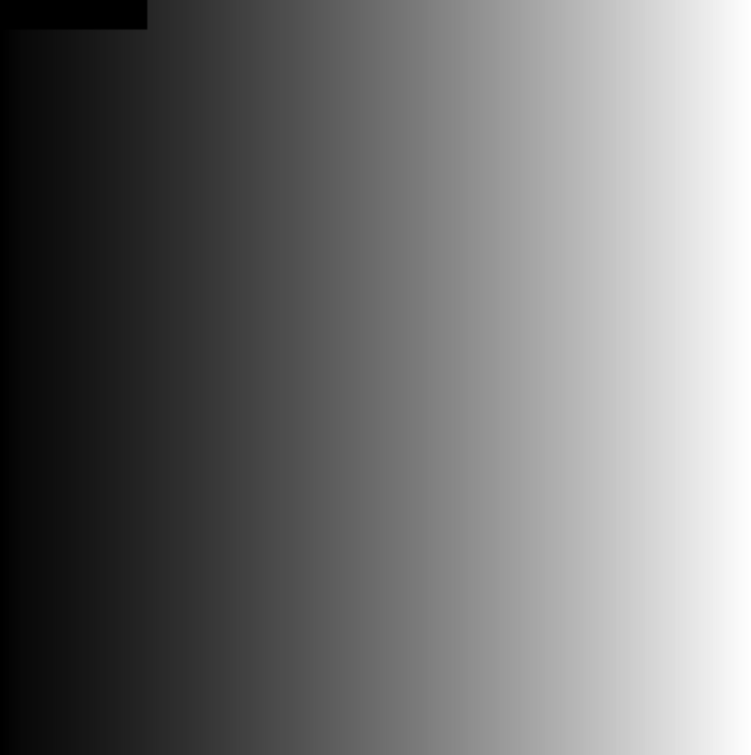

```r
f = mockFile(sizeX = 256, sizeY = 256)
img = read.image(f)

require("EBImage")
display(img, method = "raster")
```

Note that the native image data range is different depending on pixel type:

|  | int8 | uint8 | int16 | uint16 | int32 | uint32 | float | double |
| --- | --- | --- | --- | --- | --- | --- | --- | --- |
| min | -128 | 0 | -32768 | 0 | -2147483648 | 0 | -2147483648 | -2147483648 |
| max | 127 | 255 | 32767 | 65535 | 2147483647 | 4294967295 | 2147483647 | 2147483647 |

Image data returned by *RBioFormats* is by default scaled to the [0:1] range. This behavior can be controlled using the `normalize` argument to `read.image`.

```r
sapply(types, function(t) {
  img = read.image(mockFile(sizeX = 65536, sizeY = 11, pixelType = t), normalize = FALSE)
  if (typeof(img)=="raw") img = readBin(img, what = "int", n = length(img), size = 1L)
  setNames(range(img), c("min", "max"))
})
```

```
##     int8 uint8  int16 uint16       int32 uint32 float double
## min -128     0 -32768      0 -2147483648      0     0      0
## max  127   255  32767  65535           0  65535 65535  65535
```

# Appendix B: Compared to *EBImage*

Loading images using *RBioFormats* should give the same results as using the *EBImage* package.

```r
require("EBImage")
f = system.file("images", "sample-color.png", package = "EBImage")
identical(readImage(f), as.Image(read.image(f)))
```

```
## [1] TRUE
```

Performance relative to *EBImage*

```r
require("microbenchmark")
microbenchmark(read.image(f), readImage(f), times = 10)
```

[output not shown]